# Udacity Data Analyst Nanodegree

# **Act Report**

## Project 4: `WeRateDogs` Twitter Analysis - Data Wrangling - Gater, asses, clean and analyse tweets about dog ratings

> **`What its all about`**:  
> The dataset that you will be wrangling (and analyzing and visualizing) is the tweet archive of Twitter user @dog_rates, also known as WeRateDogs. WeRateDogs is a Twitter account that rates people's dogs with a humorous comment about the dog. These ratings almost always have a denominator of 10. The numerators, though? Almost always greater than 10. 11/10, 12/10, 13/10, etc. Why? Because "they're good dogs Brent." WeRateDogs has over 4 million followers and has received international media 'coverage. WeRateDogs downloaded their Twitter archive and sent it to Udacity via email exclusively for you to use in this project. This archive contains basic tweet data (tweet ID, timestamp, text, etc.) for all 5000+ of their tweets as they stood on August 1, 2017.

(cited from Udacity, on January 24, 2021)

```python
# import the libraries we need to show the plots we created

import matplotlib.pyplot as plt
import matplotlib.image as mpimg
```

## Three main questions to answer with the `WeRateDogs` dataset:

> **`Key questions`**
> 1. How does the distribution of `retweets` and `likes` look like?
> 2. Who is the most retweeted dog?
> 3. Who are the top rated dogs?

#### 1. How does the distribution of `retweets` and `likes` look like?

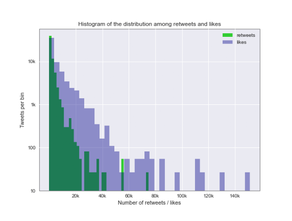

```python
plt.figure(figsize=(10,10));
distrib = mpimg.imread("Favorite_and_Retweet_Count.png");
plt.imshow(distrib);
plt.axis("off");
```

> **`Key findings`** Most of the tweets range across the lower border of retweets and likes, but some reach a very high level of likes (above 140k). As expected like rates are higher than retweeting, because giving a like is much faster and easier and less effort than retweeting. Next, lets have a look who the most retweeted dog is.

#### 2. Who is the most retweeted dog ?

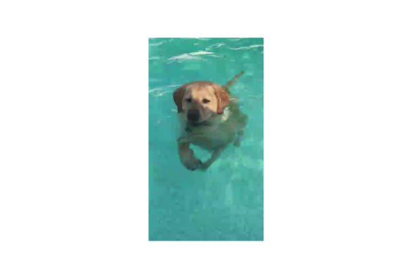

```python
plt.figure(figsize=(10,10));
img = mpimg.imread("Most_retweeted_dog.png");
plt.imshow(img);
plt.axis("off");
```

> **`Key findings`** Hello Dog! This is the most retweeted dog. However, unfortunately he / she does not have a name provided in the tweets.

#### 3. Who are the top rated dogs?

```python
img1 = mpimg.imread("top30_predicted_dog_by_counts.png")
img2 = mpimg.imread("Top30_most_rated_dogs.png")
img3 = mpimg.imread("Top30_most_rated_dogs_atleast15.png")
```

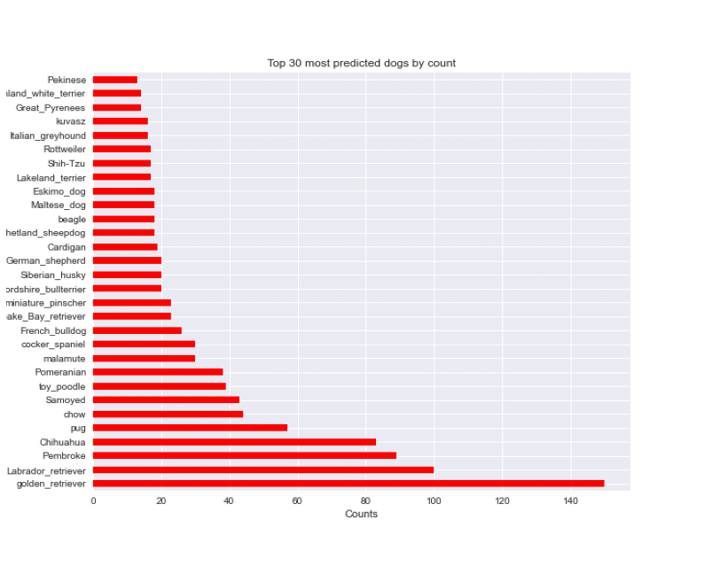

```python
plt.figure(figsize=(14,14));
plt.imshow(img1);
plt.axis("off");
```

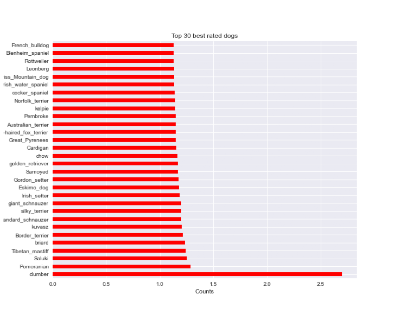

```python
plt.figure(figsize=(14,14));
plt.imshow(img2);
plt.axis("off");
```

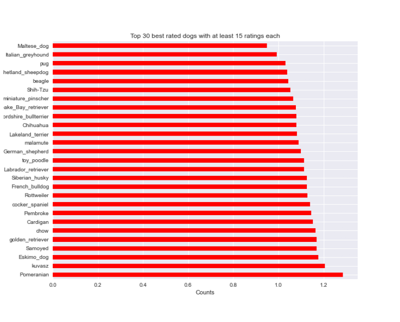

```python
plt.figure(figsize=(14,14));
plt.imshow(img3);
plt.axis("off");
```

## >**`Key findings`** As we can see from the three plots above golden retriever with a large head start the the most often predicted dogs, followed with a huge distance by labrador retrievers and pembrokes. Without considering the amount of these predictions, the 30 top rated dogs are visualised in the second figure: Dumbers are with a hugh distance the best rated dogs (with a ratio of above 2.5 (from the self created rating column)). However this might be biased, as it could have been only one very cute dog that got this rating. Therefore, for the third and last plot I only selected dog breeds that have been predicted at least 15 times or more. We can then see that the top rated dog breed no longer is dumber, but pomeranian.

> **To conclude, here are some cute pomerians. No surprise, they recieve the first place ...**

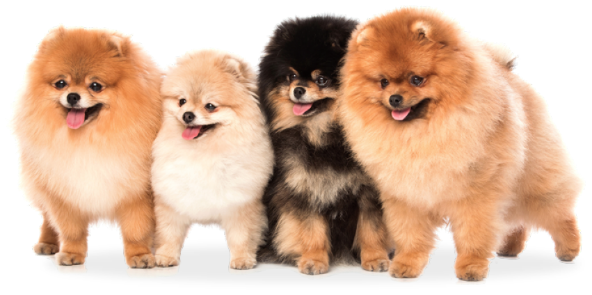

```python
import requests
from PIL import Image
from io import BytesIO

resp = requests.get("https://luxpomm.de/static/img/index/greetings-dogs.png")
i = Image.open(BytesIO(resp.content))

plt.figure(figsize=(15,15))
plt.imshow(i);
plt.axis("off");
```